# Social Media Trees Pilot

24 person pilot run, with seperate vs integrated blocks https://app.gorilla.sc/admin/experiment/238955/design

Later, update this to use base R and download the data direct from github

Read in data using eyethinkdata tools

```r
library(eyethinkdata)
data <- data_collator_gorilla("data")
```

# Social Media presentation

Make pres_data_full by filtering gorilla task data to get the information about social media posts. This has one row per social media reaction, share, comment, or continue.

We want the data with one row per post, and all the reactions in different columns. Let’s start with the exposure duration, how long they looked at each post before pressing continue button.

```r
pres_data <- data$data_task[Display=="post_single" &  Response.Type=="continue",
                            .(pid,datetime=Local.Date.and.Time,trial=Trial.Number,
                                                    trial_type=Spreadsheet..type,
                                                    postID=Spreadsheet..accountName, # change later to an item tag
                                                    exposure_time=rt)]
```

```r
react_data <- data$data_task[Display=="post_single" &  Response.Type=="action" & Tag =="react",
                            .(pid,trial=Trial.Number,reaction=paste0("react_",Response),rt,react=1)]
pres_data <- pid_merge(pres_data,dcast(react_data,
                                       formula = pid+trial~reaction,value.var = "react"),
                       link = c("pid","trial"))
pres_data[is.na(pres_data),] <- 0
```

Let’s do the same with the shares

```r
share_data <- data$data_task[Display=="post_single" &  Response.Type=="action" & Tag =="share",
                            .(pid,trial=Trial.Number,share=1)]
pres_data <- pid_merge(pres_data,share_data,
                       link = c("pid","trial"))
pres_data[is.na(share),share:=0]
```

Now if any comments are made, we can add them to pres_data

```r
comment_data <- data$data_task[Display=="post_single" &  Response.Type=="action" & Tag =="comment",
                            .(pid,trial=Trial.Number,comment = Response)]
pres_data <- pid_merge(pres_data,comment_data,link = c("pid","trial"))
pres_data[is.na(comment)]$comment_made <- 0
```

[output not shown]

# Demographics and behavioural intentions

```r
data_behav <- dcast(data_behav
      pid~Question.Key,value.var = "Response")
```

[output not shown]

# Memory

Labeling the memory items - we won’t need this after pilot data as labels will be embedded

```r
mitem <- read.csv("https://raw.githubusercontent.com/dcr-eyethink/crisps/refs/heads/master/SM%20pilot/memkey.csv")
```

[output not shown]

Now we can get the memory data performance and process it

```r
mem_data <- mem_data[Display=="test item" &  (Response=="true" | Response=="false"),
                            .(pid,trial=Trial.Number,
                              type,memitem,
                              response=ifelse(Response=="true",TRUE,FALSE),
                              acc=Correct,rt)]
```

Score the memory data

```r
memacc_data <- dcast(mem_data,pid~type,value.var = "acc",fun.aggregate = mean)
setnames(memacc_data,old=c("filler","trees"),new=c("mem_acc_filler","mem_acc_trees"))
memrt_data <-dcast(mem_data[acc==1],pid~type,value.var = "rt",fun.aggregate = mean)
setnames(memrt_data,old=c("filler","trees"),new=c("mem_rt_filler","mem_rt_trees"))
```

I don’t think that we need dprime here

```r
  mdw <- mdw[,psycho::dprime(n_hit=hit,n_miss=miss,n_fa = fa,n_cr = cr),by=.(pid,type)]
```

[output not shown]

# Combine into participants data

Now we want to combine all these data sources into one dataframe with one row per participant

```r
pd <- pid_merge(data$data_q[,.(design=unique(randomiser.wisg)),by=.(pid)],
                data_demo,
dcast(pres_data[trial_type=="filler" | trial_type=="trees"],pid~trial_type,fun.aggregate = mean,value.var =  c("exposure_time", "react", "share",  "comment_made"  )),
data_behav,
memacc_data,
memrt_data)
pd <- pd[!is.na(pid)]
write.csv(pd,"participant_data.csv")
```

# Analyse the data

Lets see how the design effects things…

## Exposure time

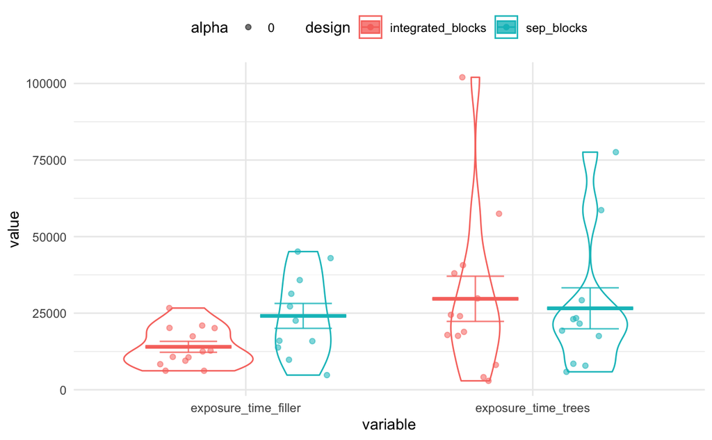

```r
pirateye(pd,x_condition = "variable", colour_condition = "design",dv=c("exposure_time_filler","exposure_time_trees"))
```

## Reactions, shares, comments

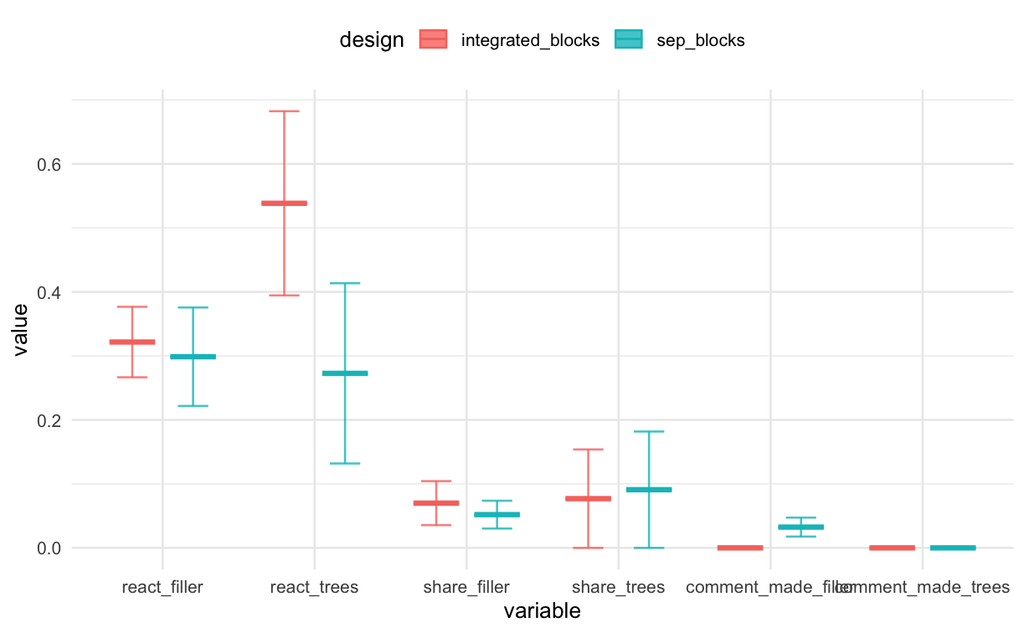

```r
pirateye(pd, colour_condition = "design",x_condition = "variable",
         dv=c("react_filler","react_trees","share_filler",  "share_trees",
              "comment_made_filler",  "comment_made_trees"  ),violin = F,dots=F)
```